# Fit Income Distribution from Gini

Ben Mazzotta

Wednesday, October 15, 2014

## Overview

Personal income data can be fit most accurately to a lognormal distribution of income, when calibrating to the Gini coefficient on income (Eric Kemp-Benedict 2001). The evidence for this is quantile regression of the Lorenz curve that generates the Gini coefficient, when compared to similar analysis for the gamma, Pareto and beta distributions. The lognormal distribution has a distinct advantage over polynomial distributions in that it is characterized by just two parameters, $\mu$ and $\sigma$.

## Model

Kemp-Benedict (2001:7) shows that the Gini index depends only on the parameter $\sigma$ of the lognormal distribution.

$g = 2 \Phi \left( \frac{\sigma}{\sqrt 2} \right) -1$

And hence to calculate $\sigma$ from a known Gini coefficient, we would invert as follows.

$\sigma = \sqrt{2} \Phi^{-1} \left( \frac{g+1}{2} \right)$

The corresponding R code is:

`sigma = sqrt(2) * qnorm( (g+1)/2 )`

## Parameters

The scale and location parameters of the lognormal distribution are $\mu$ and $\sigma$. From Kemp above we can calculate $\sigma$.

We also know that average income is a function of $\mu$ and $\sigma$. So inverting, we can derive:

$E(I) = \exp{\mu + \frac{\sigma^2}{2}}$

$\mu = log(E(I)) - \frac{\sigma^2}{2}$

And hence the procedure should be to calculate:

1. Sigma from Gini coefficient
2. Mu from GNI/capita and sigma
3. Quantiles from known distribution I = f(mu, sigma; X).

```r
inc <- inc2010[!is.na(gini),]

##      Step 1: calculate sigma from Gini coefficient.
##          (BDM: is this possible w/o scale parameter?)
inc[,sigma:= sqrt(2)*qnorm((gini/100+1)/2)]
```

```
##      iso2c       country year    income inccap  gini     saving savrate
##   1:    AF   Afghanistan 2010 6.286e+09  406.7 27.82 -2.347e+09 -14.930
##   2:    AL       Albania 2010 8.991e+09 3012.3 31.15  1.588e+09  18.167
##   3:    AM       Armenia 2010 5.215e+09 2123.8 33.52  1.404e+09  19.525
##   4:    AO        Angola 2010 2.981e+10 2179.2 50.65  1.067e+10  21.644
##   5:    AR     Argentina 2010 1.602e+11 5748.6 49.00  1.031e+10   5.547
##  ---
## 134:    VE Venezuela, RB 2010 1.528e+11 7208.5 47.68  6.879e+10  33.084
## 135:    VN       Vietnam 2010 6.072e+10  846.9 36.26  2.316e+10  30.283
## 136:    YE   Yemen, Rep. 2010 1.514e+10  850.8 35.91  2.990e+09  25.828
## 137:    ZA  South Africa 2010 2.504e+11 4810.8 63.33  3.804e+10  15.693
## 138:    ZM        Zambia 2010 7.361e+09  715.4 51.23  2.157e+09  17.171
##       savers  sigma
##   1:  2.8194 0.5035
##   2:  8.5616 0.5669
##   3:  0.8191 0.6127
##   4: 15.9156 0.9684
##   5:  3.8007 0.9317
##  ---
## 134: 13.5693 0.9028
## 135:  7.7408 0.6666
## 136:  1.0740 0.6596
## 137: 22.0800 1.2766
## 138: 11.7659 0.9815
```

```r
summary(inc)
```

```
##     iso2c             country               year          income
##  Length:138         Length:138         Min.   :2010   Min.   :1.20e+08
##  Class :character   Class :character   1st Qu.:2010   1st Qu.:4.74e+09
##  Mode  :character   Mode  :character   Median :2010   Median :1.65e+10
##                                        Mean   :2010   Mean   :2.45e+11
##                                        3rd Qu.:2010   3rd Qu.:9.99e+10
##                                        Max.   :2010   Max.   :1.31e+13
##                                                       NA's   :1
##      inccap           gini          saving             savrate
##  Min.   :  159   Min.   :25.0   Min.   :-2.35e+09   Min.   :-14.9
##  1st Qu.:  787   1st Qu.:33.8   1st Qu.: 1.13e+09   1st Qu.: 15.3
##  Median : 2261   Median :39.3   Median : 4.17e+09   Median : 19.9
##  Mean   : 7391   Mean   :40.5   Mean   : 6.71e+10   Mean   : 21.4
##  3rd Qu.: 5907   3rd Qu.:45.9   3rd Qu.: 3.24e+10   3rd Qu.: 25.3
##  Max.   :66520   Max.   :64.3   Max.   : 2.28e+12   Max.   : 76.2
##                                 NA's   :8           NA's   :8
##      savers          sigma
##  Min.   : 0.29   Min.   :0.451
##  1st Qu.: 5.42   1st Qu.:0.619
##  Median :10.82   Median :0.727
##  Mean   :15.12   Mean   :0.759
##  3rd Qu.:19.03   3rd Qu.:0.864
##  Max.   :63.58   Max.   :1.303
##  NA's   :16
```

```r
##      Step 2: calculate mu from sigma and mean
inc[,mu:=log(inccap)-(sigma^2/2)]
```

```
##      iso2c       country year    income inccap  gini     saving savrate
##   1:    AF   Afghanistan 2010 6.286e+09  406.7 27.82 -2.347e+09 -14.930
##   2:    AL       Albania 2010 8.991e+09 3012.3 31.15  1.588e+09  18.167
##   3:    AM       Armenia 2010 5.215e+09 2123.8 33.52  1.404e+09  19.525
##   4:    AO        Angola 2010 2.981e+10 2179.2 50.65  1.067e+10  21.644
##   5:    AR     Argentina 2010 1.602e+11 5748.6 49.00  1.031e+10   5.547
##  ---
## 134:    VE Venezuela, RB 2010 1.528e+11 7208.5 47.68  6.879e+10  33.084
## 135:    VN       Vietnam 2010 6.072e+10  846.9 36.26  2.316e+10  30.283
## 136:    YE   Yemen, Rep. 2010 1.514e+10  850.8 35.91  2.990e+09  25.828
## 137:    ZA  South Africa 2010 2.504e+11 4810.8 63.33  3.804e+10  15.693
## 138:    ZM        Zambia 2010 7.361e+09  715.4 51.23  2.157e+09  17.171
##       savers  sigma    mu
##   1:  2.8194 0.5035 5.881
##   2:  8.5616 0.5669 7.850
##   3:  0.8191 0.6127 7.473
##   4: 15.9156 0.9684 7.218
##   5:  3.8007 0.9317 8.223
##  ---
## 134: 13.5693 0.9028 8.475
## 135:  7.7408 0.6666 6.519
## 136:  1.0740 0.6596 6.529
## 137: 22.0800 1.2766 7.664
## 138: 11.7659 0.9815 6.091
```

```r
summary(inc)
```

```
##     iso2c             country               year          income
##  Length:138         Length:138         Min.   :2010   Min.   :1.20e+08
##  Class :character   Class :character   1st Qu.:2010   1st Qu.:4.74e+09
##  Mode  :character   Mode  :character   Median :2010   Median :1.65e+10
##                                        Mean   :2010   Mean   :2.45e+11
##                                        3rd Qu.:2010   3rd Qu.:9.99e+10
##                                        Max.   :2010   Max.   :1.31e+13
##                                                       NA's   :1
##      inccap           gini          saving             savrate
##  Min.   :  159   Min.   :25.0   Min.   :-2.35e+09   Min.   :-14.9
##  1st Qu.:  787   1st Qu.:33.8   1st Qu.: 1.13e+09   1st Qu.: 15.3
##  Median : 2261   Median :39.3   Median : 4.17e+09   Median : 19.9
##  Mean   : 7391   Mean   :40.5   Mean   : 6.71e+10   Mean   : 21.4
##  3rd Qu.: 5907   3rd Qu.:45.9   3rd Qu.: 3.24e+10   3rd Qu.: 25.3
##  Max.   :66520   Max.   :64.3   Max.   : 2.28e+12   Max.   : 76.2
##                                 NA's   :8           NA's   :8
##      savers          sigma             mu
##  Min.   : 0.29   Min.   :0.451   Min.   : 4.89
##  1st Qu.: 5.42   1st Qu.:0.619   1st Qu.: 6.38
##  Median :10.82   Median :0.727   Median : 7.39
##  Mean   :15.12   Mean   :0.759   Mean   : 7.49
##  3rd Qu.:19.03   3rd Qu.:0.864   3rd Qu.: 8.38
##  Max.   :63.58   Max.   :1.303   Max.   :11.00
##  NA's   :16
```

```r
##      Step 3: Read quantiles from mu and sigma
inc[,p20:=qlnorm(.20, mu, sigma)]
```

```
##      iso2c       country year    income inccap  gini     saving savrate
##   1:    AF   Afghanistan 2010 6.286e+09  406.7 27.82 -2.347e+09 -14.930
##   2:    AL       Albania 2010 8.991e+09 3012.3 31.15  1.588e+09  18.167
##   3:    AM       Armenia 2010 5.215e+09 2123.8 33.52  1.404e+09  19.525
##   4:    AO        Angola 2010 2.981e+10 2179.2 50.65  1.067e+10  21.644
##   5:    AR     Argentina 2010 1.602e+11 5748.6 49.00  1.031e+10   5.547
##  ---
## 134:    VE Venezuela, RB 2010 1.528e+11 7208.5 47.68  6.879e+10  33.084
## 135:    VN       Vietnam 2010 6.072e+10  846.9 36.26  2.316e+10  30.283
## 136:    YE   Yemen, Rep. 2010 1.514e+10  850.8 35.91  2.990e+09  25.828
## 137:    ZA  South Africa 2010 2.504e+11 4810.8 63.33  3.804e+10  15.693
## 138:    ZM        Zambia 2010 7.361e+09  715.4 51.23  2.157e+09  17.171
##       savers  sigma    mu    p20
##   1:  2.8194 0.5035 5.881  234.5
##   2:  8.5616 0.5669 7.850 1591.8
##   3:  0.8191 0.6127 7.473 1051.1
##   4: 15.9156 0.9684 7.218  603.5
##   5:  3.8007 0.9317 8.223 1700.3
##  ---
## 134: 13.5693 0.9028 8.475 2243.1
## 135:  7.7408 0.6666 6.519  387.0
## 136:  1.0740 0.6596 6.529  392.8
## 137: 22.0800 1.2766 7.664  727.2
## 138: 11.7659 0.9815 6.091  193.5
```

```r
inc[,psav:=qlnorm(1-savers/100, mu, sigma)]
```

```
##      iso2c       country year    income inccap  gini     saving savrate
##   1:    AF   Afghanistan 2010 6.286e+09  406.7 27.82 -2.347e+09 -14.930
##   2:    AL       Albania 2010 8.991e+09 3012.3 31.15  1.588e+09  18.167
##   3:    AM       Armenia 2010 5.215e+09 2123.8 33.52  1.404e+09  19.525
##   4:    AO        Angola 2010 2.981e+10 2179.2 50.65  1.067e+10  21.644
##   5:    AR     Argentina 2010 1.602e+11 5748.6 49.00  1.031e+10   5.547
##  ---
## 134:    VE Venezuela, RB 2010 1.528e+11 7208.5 47.68  6.879e+10  33.084
## 135:    VN       Vietnam 2010 6.072e+10  846.9 36.26  2.316e+10  30.283
## 136:    YE   Yemen, Rep. 2010 1.514e+10  850.8 35.91  2.990e+09  25.828
## 137:    ZA  South Africa 2010 2.504e+11 4810.8 63.33  3.804e+10  15.693
## 138:    ZM        Zambia 2010 7.361e+09  715.4 51.23  2.157e+09  17.171
##       savers  sigma    mu    p20    psav
##   1:  2.8194 0.5035 5.881  234.5   936.3
##   2:  8.5616 0.5669 7.850 1591.8  5571.6
##   3:  0.8191 0.6127 7.473 1051.1  7661.2
##   4: 15.9156 0.9684 7.218  603.5  3584.0
##   5:  3.8007 0.9317 8.223 1700.3 19453.7
##  ---
## 134: 13.5693 0.9028 8.475 2243.1 12944.9
## 135:  7.7408 0.6666 6.519  387.0  1750.7
## 136:  1.0740 0.6596 6.529  392.8  3119.4
## 137: 22.0800 1.2766 7.664  727.2  5687.8
## 138: 11.7659 0.9815 6.091  193.5  1416.5
```

```r
summary(inc)
```

```
##     iso2c             country               year          income
##  Length:138         Length:138         Min.   :2010   Min.   :1.20e+08
##  Class :character   Class :character   1st Qu.:2010   1st Qu.:4.74e+09
##  Mode  :character   Mode  :character   Median :2010   Median :1.65e+10
##                                        Mean   :2010   Mean   :2.45e+11
##                                        3rd Qu.:2010   3rd Qu.:9.99e+10
##                                        Max.   :2010   Max.   :1.31e+13
##                                                       NA's   :1
##      inccap           gini          saving             savrate
##  Min.   :  159   Min.   :25.0   Min.   :-2.35e+09   Min.   :-14.9
##  1st Qu.:  787   1st Qu.:33.8   1st Qu.: 1.13e+09   1st Qu.: 15.3
##  Median : 2261   Median :39.3   Median : 4.17e+09   Median : 19.9
##  Mean   : 7391   Mean   :40.5   Mean   : 6.71e+10   Mean   : 21.4
##  3rd Qu.: 5907   3rd Qu.:45.9   3rd Qu.: 3.24e+10   3rd Qu.: 25.3
##  Max.   :66520   Max.   :64.3   Max.   : 2.28e+12   Max.   : 76.2
##                                 NA's   :8           NA's   :8
##      savers          sigma             mu             p20
##  Min.   : 0.29   Min.   :0.451   Min.   : 4.89   Min.   :   79
##  1st Qu.: 5.42   1st Qu.:0.619   1st Qu.: 6.38   1st Qu.:  298
##  Median :10.82   Median :0.727   Median : 7.39   Median :  791
##  Mean   :15.12   Mean   :0.759   Mean   : 7.49   Mean   : 3503
##  3rd Qu.:19.03   3rd Qu.:0.864   3rd Qu.: 8.38   3rd Qu.: 2242
##  Max.   :63.58   Max.   :1.303   Max.   :11.00   Max.   :40348
##  NA's   :16
##       psav
##  Min.   :  317
##  1st Qu.: 1762
##  Median : 4263
##  Mean   : 9190
##  3rd Qu.:11876
##  Max.   :74809
##  NA's   :16
```

```r
summary(1-inc$savers/100)
```

```
##    Min. 1st Qu.  Median    Mean 3rd Qu.    Max.    NA's
##   0.364   0.810   0.892   0.849   0.946   0.997      16
```

So the object `inc` in memory has accurate parameters for the lognormal distribution of per capita income in memory.

It also has the 20th percentile of per capita income, and the nth percentile of per capita income, where $n$ corresponds to the share of the population that do not save at a formal financial institution.

Are these estimates plausible?

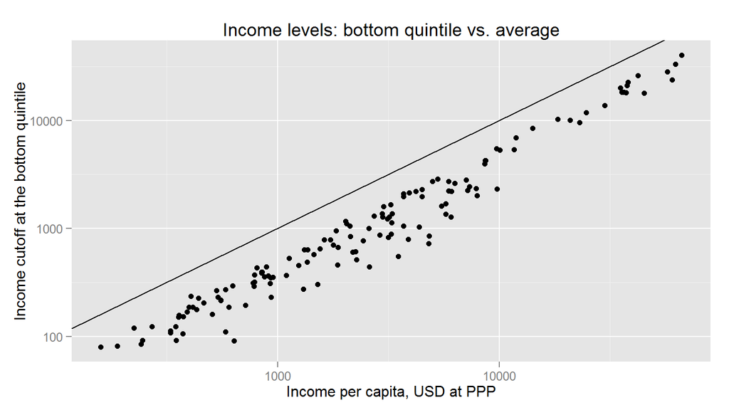

```r
## Plot p20 vs income per capita.
##      Has to be all below 45 degree line
qplot(inccap, p20, data=inc, geom="point", log="xy")+geom_abline(intercept=0,slope=1)+
  labs(list(title="Income levels: bottom quintile vs. average", x="Income per capita, USD at PPP", y="Income cutoff at the bottom quintile"))
```

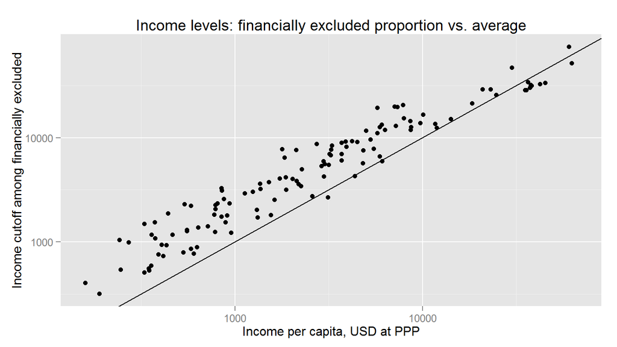

```r
## Plot psavers vs income per capita.
##      Rich countries below the line, poor countries above
qplot(inccap, psav, data=inc, geom="point", log="xy")+geom_abline(intercept=0,slope=1)+
  labs(list(title="Income levels: financially excluded proportion vs. average", x="Income per capita, USD at PPP", y="Income cutoff among financially excluded"))
```

## Simulate distributions

Now let’s take the distribution parameters mu and sigma for each country. Using a large-enough population, simulate the share of income accruing to the bottom quintile of the distribution.

```r
# inc.siminput <- inc[,.SD, .SDcols=c("mu","sigma")]

## Make a list of simulated income data
##      Each of length 10^6, using the observed values of mu and sigma
test <- mapply(rlnorm, rep(1e6, nrow(inc)), inc$mu, inc$sigma)
##      It's very large.
dim(test)
```

```
## [1] 1000000     138
```

```r
object.size(test)/1e6
```

```
## 1104.0002 bytes
```

```r
##      It took several seconds to compute the summary statistics.
# summary(test)
test <- data.table(test)

test.sums <- colSums(test)

str(inc$p20)
```

```
##  num [1:138] 234 1592 1051 604 1700 ...
```

```r
head(inc$p20)
```

```
## [1]   234.5  1591.8  1051.1   603.5  1700.3 21002.9
```

```r
##    How to use data.table to get fast sums of subsets?
test[V1<235,sum(V1)]
```

```
## [1] 36510408
```

```r
## You can run this code to get the sum of bottom quintile values in a single column
myvar <- "V1"
test[get(myvar)<234.4945, sum(.SD), .SDcols=myvar]
```

```
## [1] 36227776
```

```r
# What if I just had the number 1 as an input?
test[get(paste("V",1,sep=""))<inc$p20[1], sum(.SD), .SDcols=paste("V",1,sep="")]
```

```
## [1] 36227776
```

```r
## Write a function to do this.
calc.p20sum <- function(x) test[get(paste("V",x,sep=""))<inc$p20[x], sum(.SD), .SDcols=paste("V",x,sep="")]

# Does it still work? Yes. :)
calc.p20sum(1)
```

```
## [1] 36227776
```

```r
test.sump20 <- sapply(c(1:length(inc$p20)), calc.p20sum)
summary(test.sump20)
```

```
##     Min.  1st Qu.   Median     Mean  3rd Qu.     Max.
## 1.02e+07 3.99e+07 1.02e+08 5.17e+08 3.18e+08 6.37e+09
```

```r
test.p20share <- test.sump20/test.sums
test.p20share *100
```

```
##    V1    V2    V3    V4    V5    V6    V7    V8    V9   V10   V11   V12
## 8.901 7.957 7.246 3.522 3.813 8.529 6.979 7.666 7.461 7.428 5.741 7.874
##   V13   V14   V15   V16   V17   V18   V19   V20   V21   V22   V23   V24
## 7.369 5.439 2.514 2.526 5.414 2.050 8.782 7.547 4.694 3.638 4.834 7.251
##   V25   V26   V27   V28   V29   V30   V31   V32   V33   V34   V35   V36
## 4.407 3.139 5.531 5.366 2.446 3.764 4.160 9.412 8.775 5.672 3.622 3.257
##   V37   V38   V39   V40   V41   V42   V43   V44   V45   V46   V47   V48
## 6.688 7.721 6.975 7.964 9.236 4.608 1.974 5.152 5.435 5.050 4.127 6.180
##   V49   V50   V51   V52   V53   V54   V55   V56   V57   V58   V59   V60
## 7.080 2.741 6.752 2.386 7.913 2.213 8.712 7.090 7.122 5.861 7.254 8.253
##   V61   V62   V63   V64   V65   V66   V67   V68   V69   V70   V71   V72
## 6.070 6.627 2.904 6.659 4.054 6.710 6.074 1.600 7.654 6.864 5.841 6.120
##   V73   V74   V75   V76   V77   V78   V79   V80   V81   V82   V83   V84
## 3.076 7.228 8.082 6.596 5.500 6.855 8.274 4.564 5.553 6.279 7.010 5.614
##   V85   V86   V87   V88   V89   V90   V91   V92   V93   V94   V95   V96
## 6.646 6.296 5.077 3.851 4.897 4.299 1.796 6.507 5.017 4.990 9.585 6.061
##   V97   V98   V99  V100  V101  V102  V103  V104  V105  V106  V107  V108
## 2.868 3.451 4.759 8.055 7.146 6.496 3.061 5.407 8.251 8.067 5.806 3.311
##  V109  V110  V111  V112  V113  V114  V115  V116  V117  V118  V119  V120
## 2.920 6.808 9.804 8.575 8.967 5.901 5.599 4.481 5.151 3.867 6.708 3.432
##  V121  V122  V123  V124  V125  V126  V127  V128  V129  V130  V131  V132
## 5.315 5.635 5.368 7.654 8.127 5.840 5.475 6.477 8.905 4.741 5.514 4.398
##  V133  V134  V135  V136  V137  V138
## 6.740 4.047 6.559 6.642 1.702 3.406
```

```r
## And to do the same thing for the proportion saving:

## This function returns the gross income beneath the nth percentile of income,
##      Where n is the percentage of those that do not save.
calc.finexsum <- function(x) test[get(paste("V",x,sep=""))<inc$psav[x], sum(.SD), .SDcols=paste("V",x,sep="")]

# Does it still work? Yes. :)
calc.finexsum(1)
```

```
## [1] 374433331
```

```r
# calc.finexsum(17)

# inc$psav

## Running the same command as above threw an error
##      Not all the psav observations are defined.
##      Need to substitute something when undefined.....
test.sumfinex <- sapply(which(!is.na(inc$psav)), calc.finexsum)
summary(test.sumfinex)
```

```
##     Min.  1st Qu.   Median     Mean  3rd Qu.     Max.
## 1.23e+08 5.60e+08 1.45e+09 3.16e+09 4.23e+09 2.77e+10
```

```r
test.finexshare <- rep(NA, nrow(inc))
test.finexshare[which(!is.na(inc$psav))] <- test.sumfinex / test.sums[which(!is.na(inc$psav))]

options(digits=3)
test.finexshare*100
```

```
##   [1] 92.0 78.9 96.3 51.3 80.0 28.5 93.4 83.2 64.4 33.9 75.1 86.2 89.1 76.2
##  [15] 43.4 56.0   NA 41.0 83.6 25.0 91.0 84.5 78.2   NA   NA 55.3 70.2 38.0
##  [29] 58.0 46.5   NA 45.8 25.5 86.1 51.5 52.2 45.9 97.0 40.0   NA 26.1   NA
##  [43]   NA 71.7 94.0 57.6   NA 91.0 58.7 57.5   NA 59.1 72.4 39.8 66.6 65.3
##  [57] 25.5 48.3 71.8 85.5 55.8 63.8 29.4 76.7 43.2 95.6 95.5 47.7 81.9 58.6
##  [71] 44.1 64.7 64.9 58.1 27.1 67.3 65.8 87.6 90.2 91.3 75.0 84.3 53.9 78.1
##  [85] 43.7   NA 72.3 71.6 33.1 52.5   NA 94.5 46.7 76.0   NA 71.9 53.7 65.4
##  [99] 58.8 94.8 61.6 82.3 60.6 45.9 79.3 90.3 69.2 47.0   NA 88.0 21.3 51.4
## [113] 43.5 63.2 85.1   NA   NA 58.1 83.7 47.8 76.2 85.3 27.8 98.6   NA 82.0
## [127] 83.4 69.3 86.5 56.0 22.1 76.5 95.9 57.8 77.5 94.9 30.6 58.1
```

## Quantile estimation

The procedure above transforms the Gini coefficient into the $\sigma$ parameter of a lognormal distribution.

R provides built-in functions for estimating quantiles of lognormal distribution with known parameters $\mu$ and $\sigma$.

Consequently, if we are given the share of the population that are financially excluded, $p$, the average income, and the Gini coefficient, we can derive both the $\mu$ and $\sigma$ parameters of the income distribution. Together these are sufficient to determine the share of national income available to the financially excluded. From the saving rate, we can derive an upper bound on the amount lost to cash hoards.

Let’s assume that the Kemp-Benedict formula is correct. Based on that …

```r
## Calculate mean and variance
##        Sufficient to model the distribution
inc2010[,mu:=inccap]
```

```
##      iso2c                                        country year   income
##   1:    1A                                     Arab World 2010 1.17e+12
##   2:    1W                                          World 2010 4.74e+13
##   3:    4E          East Asia & Pacific (developing only) 2010 3.58e+12
##   4:    7E        Europe & Central Asia (developing only) 2010 1.01e+12
##   5:    8S                                     South Asia 2010 1.16e+12
##  ---
## 254:    ZG         Sub-Saharan Africa (all income levels) 2010 6.64e+11
## 255:    ZJ  Latin America & Caribbean (all income levels) 2010 2.86e+12
## 256:    ZM                                         Zambia 2010 7.36e+09
## 257:    ZQ Middle East & North Africa (all income levels) 2010 1.47e+12
## 258:    ZW                                       Zimbabwe 2010 6.14e+09
##      inccap gini   saving savrate savers   mu
##   1:   4311  NaN      NaN    34.6    NaN 4311
##   2:   7562  NaN      NaN    23.4  22.43 7562
##   3:   2313  NaN      NaN    44.0  28.45 2313
##   4:   4105  NaN      NaN    19.0   6.98 4105
##   5:    840  NaN      NaN    30.3  11.09  840
##  ---
## 254:    901  NaN      NaN    18.5    NaN  901
## 255:   5788  NaN      NaN    19.0    NaN 5788
## 256:    715 51.2 2.16e+09    17.2  11.77  715
## 257:   4924  NaN      NaN    34.8    NaN 4924
## 258:    490  NaN      NaN     NaN  17.27  490
```

```r
inc2010[,sigma:=sqrt(2)*qnorm((gini/100+1)/2)]
```

```
##      iso2c                                        country year   income
##   1:    1A                                     Arab World 2010 1.17e+12
##   2:    1W                                          World 2010 4.74e+13
##   3:    4E          East Asia & Pacific (developing only) 2010 3.58e+12
##   4:    7E        Europe & Central Asia (developing only) 2010 1.01e+12
##   5:    8S                                     South Asia 2010 1.16e+12
##  ---
## 254:    ZG         Sub-Saharan Africa (all income levels) 2010 6.64e+11
## 255:    ZJ  Latin America & Caribbean (all income levels) 2010 2.86e+12
## 256:    ZM                                         Zambia 2010 7.36e+09
## 257:    ZQ Middle East & North Africa (all income levels) 2010 1.47e+12
## 258:    ZW                                       Zimbabwe 2010 6.14e+09
##      inccap gini   saving savrate savers   mu sigma
##   1:   4311  NaN      NaN    34.6    NaN 4311   NaN
##   2:   7562  NaN      NaN    23.4  22.43 7562   NaN
##   3:   2313  NaN      NaN    44.0  28.45 2313   NaN
##   4:   4105  NaN      NaN    19.0   6.98 4105   NaN
##   5:    840  NaN      NaN    30.3  11.09  840   NaN
##  ---
## 254:    901  NaN      NaN    18.5    NaN  901   NaN
## 255:   5788  NaN      NaN    19.0    NaN 5788   NaN
## 256:    715 51.2 2.16e+09    17.2  11.77  715 0.982
## 257:   4924  NaN      NaN    34.8    NaN 4924   NaN
## 258:    490  NaN      NaN     NaN  17.27  490   NaN
```

```r
## What are some percentiles worth knowing?
inc2010[,p20 :=.20]  ## 20th percentile
```

```
##      iso2c                                        country year   income
##   1:    1A                                     Arab World 2010 1.17e+12
##   2:    1W                                          World 2010 4.74e+13
##   3:    4E          East Asia & Pacific (developing only) 2010 3.58e+12
##   4:    7E        Europe & Central Asia (developing only) 2010 1.01e+12
##   5:    8S                                     South Asia 2010 1.16e+12
##  ---
## 254:    ZG         Sub-Saharan Africa (all income levels) 2010 6.64e+11
## 255:    ZJ  Latin America & Caribbean (all income levels) 2010 2.86e+12
## 256:    ZM                                         Zambia 2010 7.36e+09
## 257:    ZQ Middle East & North Africa (all income levels) 2010 1.47e+12
## 258:    ZW                                       Zimbabwe 2010 6.14e+09
##      inccap gini   saving savrate savers   mu sigma p20
##   1:   4311  NaN      NaN    34.6    NaN 4311   NaN 0.2
##   2:   7562  NaN      NaN    23.4  22.43 7562   NaN 0.2
##   3:   2313  NaN      NaN    44.0  28.45 2313   NaN 0.2
##   4:   4105  NaN      NaN    19.0   6.98 4105   NaN 0.2
##   5:    840  NaN      NaN    30.3  11.09  840   NaN 0.2
##  ---
## 254:    901  NaN      NaN    18.5    NaN  901   NaN 0.2
## 255:   5788  NaN      NaN    19.0    NaN 5788   NaN 0.2
## 256:    715 51.2 2.16e+09    17.2  11.77  715 0.982 0.2
## 257:   4924  NaN      NaN    34.8    NaN 4924   NaN 0.2
## 258:    490  NaN      NaN     NaN  17.27  490   NaN 0.2
```

```r
inc2010[,psav := 1- savers/100]  ## financially excluded
```

```
##      iso2c                                        country year   income
##   1:    1A                                     Arab World 2010 1.17e+12
##   2:    1W                                          World 2010 4.74e+13
##   3:    4E          East Asia & Pacific (developing only) 2010 3.58e+12
##   4:    7E        Europe & Central Asia (developing only) 2010 1.01e+12
##   5:    8S                                     South Asia 2010 1.16e+12
##  ---
## 254:    ZG         Sub-Saharan Africa (all income levels) 2010 6.64e+11
## 255:    ZJ  Latin America & Caribbean (all income levels) 2010 2.86e+12
## 256:    ZM                                         Zambia 2010 7.36e+09
## 257:    ZQ Middle East & North Africa (all income levels) 2010 1.47e+12
## 258:    ZW                                       Zimbabwe 2010 6.14e+09
##      inccap gini   saving savrate savers   mu sigma p20  psav
##   1:   4311  NaN      NaN    34.6    NaN 4311   NaN 0.2   NaN
##   2:   7562  NaN      NaN    23.4  22.43 7562   NaN 0.2 0.776
##   3:   2313  NaN      NaN    44.0  28.45 2313   NaN 0.2 0.716
##   4:   4105  NaN      NaN    19.0   6.98 4105   NaN 0.2 0.930
##   5:    840  NaN      NaN    30.3  11.09  840   NaN 0.2 0.889
##  ---
## 254:    901  NaN      NaN    18.5    NaN  901   NaN 0.2   NaN
## 255:   5788  NaN      NaN    19.0    NaN 5788   NaN 0.2   NaN
## 256:    715 51.2 2.16e+09    17.2  11.77  715 0.982 0.2 0.882
## 257:   4924  NaN      NaN    34.8    NaN 4924   NaN 0.2   NaN
## 258:    490  NaN      NaN     NaN  17.27  490   NaN 0.2 0.827
```

```r
## What is the per capita income cutoff for the bottom quintile?
##                          ... for financially excluded?
inc2010[,inc.p20 := qlnorm(p20, meanlog=log(mu), sdlog=log(sigma))]
```

```
##      iso2c                                        country year   income
##   1:    1A                                     Arab World 2010 1.17e+12
##   2:    1W                                          World 2010 4.74e+13
##   3:    4E          East Asia & Pacific (developing only) 2010 3.58e+12
##   4:    7E        Europe & Central Asia (developing only) 2010 1.01e+12
##   5:    8S                                     South Asia 2010 1.16e+12
##  ---
## 254:    ZG         Sub-Saharan Africa (all income levels) 2010 6.64e+11
## 255:    ZJ  Latin America & Caribbean (all income levels) 2010 2.86e+12
## 256:    ZM                                         Zambia 2010 7.36e+09
## 257:    ZQ Middle East & North Africa (all income levels) 2010 1.47e+12
## 258:    ZW                                       Zimbabwe 2010 6.14e+09
##      inccap gini   saving savrate savers   mu sigma p20  psav inc.p20
##   1:   4311  NaN      NaN    34.6    NaN 4311   NaN 0.2   NaN     NaN
##   2:   7562  NaN      NaN    23.4  22.43 7562   NaN 0.2 0.776     NaN
##   3:   2313  NaN      NaN    44.0  28.45 2313   NaN 0.2 0.716     NaN
##   4:   4105  NaN      NaN    19.0   6.98 4105   NaN 0.2 0.930     NaN
##   5:    840  NaN      NaN    30.3  11.09  840   NaN 0.2 0.889     NaN
##  ---
## 254:    901  NaN      NaN    18.5    NaN  901   NaN 0.2   NaN     NaN
## 255:   5788  NaN      NaN    19.0    NaN 5788   NaN 0.2   NaN     NaN
## 256:    715 51.2 2.16e+09    17.2  11.77  715 0.982 0.2 0.882     NaN
## 257:   4924  NaN      NaN    34.8    NaN 4924   NaN 0.2   NaN     NaN
## 258:    490  NaN      NaN     NaN  17.27  490   NaN 0.2 0.827     NaN
```

```r
inc2010[,inc.psav := qlnorm(psav, meanlog=log(mu), sdlog=log(sigma))]
```

```
##      iso2c                                        country year   income
##   1:    1A                                     Arab World 2010 1.17e+12
##   2:    1W                                          World 2010 4.74e+13
##   3:    4E          East Asia & Pacific (developing only) 2010 3.58e+12
##   4:    7E        Europe & Central Asia (developing only) 2010 1.01e+12
##   5:    8S                                     South Asia 2010 1.16e+12
##  ---
## 254:    ZG         Sub-Saharan Africa (all income levels) 2010 6.64e+11
## 255:    ZJ  Latin America & Caribbean (all income levels) 2010 2.86e+12
## 256:    ZM                                         Zambia 2010 7.36e+09
## 257:    ZQ Middle East & North Africa (all income levels) 2010 1.47e+12
## 258:    ZW                                       Zimbabwe 2010 6.14e+09
##      inccap gini   saving savrate savers   mu sigma p20  psav inc.p20
##   1:   4311  NaN      NaN    34.6    NaN 4311   NaN 0.2   NaN     NaN
##   2:   7562  NaN      NaN    23.4  22.43 7562   NaN 0.2 0.776     NaN
```

[output cut: 21 more lines]

```r
##      Cutoffs a multiple of per capita income:
inc2010[,incmult.p20 := inc.p20/inccap]
```

```
##      iso2c                                        country year   income
##   1:    1A                                     Arab World 2010 1.17e+12
##   2:    1W                                          World 2010 4.74e+13
##   3:    4E          East Asia & Pacific (developing only) 2010 3.58e+12
##   4:    7E        Europe & Central Asia (developing only) 2010 1.01e+12
##   5:    8S                                     South Asia 2010 1.16e+12
##  ---
## 254:    ZG         Sub-Saharan Africa (all income levels) 2010 6.64e+11
## 255:    ZJ  Latin America & Caribbean (all income levels) 2010 2.86e+12
## 256:    ZM                                         Zambia 2010 7.36e+09
## 257:    ZQ Middle East & North Africa (all income levels) 2010 1.47e+12
## 258:    ZW                                       Zimbabwe 2010 6.14e+09
##      inccap gini   saving savrate savers   mu sigma p20  psav inc.p20
##   1:   4311  NaN      NaN    34.6    NaN 4311   NaN 0.2   NaN     NaN
##   2:   7562  NaN      NaN    23.4  22.43 7562   NaN 0.2 0.776     NaN
```

[output cut: 21 more lines]

```r
inc2010[,incmult.psav := inc.psav/inccap]
```

```
##      iso2c                                        country year   income
##   1:    1A                                     Arab World 2010 1.17e+12
##   2:    1W                                          World 2010 4.74e+13
##   3:    4E          East Asia & Pacific (developing only) 2010 3.58e+12
##   4:    7E        Europe & Central Asia (developing only) 2010 1.01e+12
##   5:    8S                                     South Asia 2010 1.16e+12
##  ---
## 254:    ZG         Sub-Saharan Africa (all income levels) 2010 6.64e+11
## 255:    ZJ  Latin America & Caribbean (all income levels) 2010 2.86e+12
## 256:    ZM                                         Zambia 2010 7.36e+09
## 257:    ZQ Middle East & North Africa (all income levels) 2010 1.47e+12
## 258:    ZW                                       Zimbabwe 2010 6.14e+09
##      inccap gini   saving savrate savers   mu sigma p20  psav inc.p20
##   1:   4311  NaN      NaN    34.6    NaN 4311   NaN 0.2   NaN     NaN
##   2:   7562  NaN      NaN    23.4  22.43 7562   NaN 0.2 0.776     NaN
```

[output cut: 21 more lines]

```r
##      Cumulative share of per capita income:
inc2010[,incshare.p20 := dlnorm(p20, meanlog=log(mu), sdlog=log(sigma))]
```

```
##      iso2c                                        country year   income
##   1:    1A                                     Arab World 2010 1.17e+12
##   2:    1W                                          World 2010 4.74e+13
##   3:    4E          East Asia & Pacific (developing only) 2010 3.58e+12
##   4:    7E        Europe & Central Asia (developing only) 2010 1.01e+12
##   5:    8S                                     South Asia 2010 1.16e+12
##  ---
## 254:    ZG         Sub-Saharan Africa (all income levels) 2010 6.64e+11
## 255:    ZJ  Latin America & Caribbean (all income levels) 2010 2.86e+12
## 256:    ZM                                         Zambia 2010 7.36e+09
## 257:    ZQ Middle East & North Africa (all income levels) 2010 1.47e+12
## 258:    ZW                                       Zimbabwe 2010 6.14e+09
##      inccap gini   saving savrate savers   mu sigma p20  psav inc.p20
##   1:   4311  NaN      NaN    34.6    NaN 4311   NaN 0.2   NaN     NaN
##   2:   7562  NaN      NaN    23.4  22.43 7562   NaN 0.2 0.776     NaN
```

[output cut: 21 more lines]

```r
inc2010[,incshare.psav := dlnorm(psav, meanlog=log(mu), sdlog=log(sigma))]
```

```
##      iso2c                                        country year   income
##   1:    1A                                     Arab World 2010 1.17e+12
##   2:    1W                                          World 2010 4.74e+13
##   3:    4E          East Asia & Pacific (developing only) 2010 3.58e+12
##   4:    7E        Europe & Central Asia (developing only) 2010 1.01e+12
##   5:    8S                                     South Asia 2010 1.16e+12
##  ---
## 254:    ZG         Sub-Saharan Africa (all income levels) 2010 6.64e+11
## 255:    ZJ  Latin America & Caribbean (all income levels) 2010 2.86e+12
## 256:    ZM                                         Zambia 2010 7.36e+09
## 257:    ZQ Middle East & North Africa (all income levels) 2010 1.47e+12
## 258:    ZW                                       Zimbabwe 2010 6.14e+09
##      inccap gini   saving savrate savers   mu sigma p20  psav inc.p20
##   1:   4311  NaN      NaN    34.6    NaN 4311   NaN 0.2   NaN     NaN
##   2:   7562  NaN      NaN    23.4  22.43 7562   NaN 0.2 0.776     NaN
```

[output cut: 21 more lines]

```r
save(inc2010, file="modeled saving of finexcl.Rda")
inc2010 <- subset(inc2010, !is.na(gini))
str(inc2010); summary(inc2010)
```

```
## Classes 'data.table' and 'data.frame':   138 obs. of  19 variables:
##  $ iso2c        : chr  "AF" "AL" "AM" "AO" ...
##  $ country      : chr  "Afghanistan" "Albania" "Armenia" "Angola" ...
##  $ year         : num  2010 2010 2010 2010 2010 2010 2010 2010 2010 2010 ...
##  $ income       : num  6.29e+09 8.99e+09 5.22e+09 2.98e+10 1.60e+11 ...
##  $ inccap       : num  407 3012 2124 2179 5749 ...
##  $ gini         : num  27.8 31.1 33.5 50.6 49 ...
##  $ saving       : num  -2.35e+09 1.59e+09 1.40e+09 1.07e+10 1.03e+10 ...
##  $ savrate      : num  -14.93 18.17 19.52 21.64 5.55 ...
##  $ savers       : num  2.819 8.562 0.819 15.916 3.801 ...
##  $ mu           : num  407 3012 2124 2179 5749 ...
##  $ sigma        : num  0.504 0.567 0.613 0.968 0.932 ...
##  $ p20          : num  0.2 0.2 0.2 0.2 0.2 0.2 0.2 0.2 0.2 0.2 ...
##  $ psav         : num  0.972 0.914 0.992 0.841 0.962 ...
##  $ inc.p20      : num  NaN NaN NaN NaN NaN NaN NaN NaN NaN NaN ...
##  $ inc.psav     : num  NaN NaN NaN NaN NaN NaN NaN NaN NaN NaN ...
##  $ incmult.p20  : num  NaN NaN NaN NaN NaN NaN NaN NaN NaN NaN ...
##  $ incmult.psav : num  NaN NaN NaN NaN NaN NaN NaN NaN NaN NaN ...
##  $ incshare.p20 : num  NaN NaN NaN NaN NaN NaN NaN NaN NaN NaN ...
##  $ incshare.psav: num  NaN NaN NaN NaN NaN NaN NaN NaN NaN NaN ...
##  - attr(*, ".internal.selfref")=<externalptr>
```

```
##     iso2c             country               year          income
##  Length:138         Length:138         Min.   :2010   Min.   :1.20e+08
##  Class :character   Class :character   1st Qu.:2010   1st Qu.:4.74e+09
##  Mode  :character   Mode  :character   Median :2010   Median :1.65e+10
##                                        Mean   :2010   Mean   :2.45e+11
##                                        3rd Qu.:2010   3rd Qu.:9.99e+10
##                                        Max.   :2010   Max.   :1.31e+13
##                                                       NA's   :1
##      inccap           gini          saving             savrate
##  Min.   :  159   Min.   :25.0   Min.   :-2.35e+09   Min.   :-14.9
##  1st Qu.:  787   1st Qu.:33.8   1st Qu.: 1.13e+09   1st Qu.: 15.3
##  Median : 2261   Median :39.3   Median : 4.17e+09   Median : 19.8
##  Mean   : 7391   Mean   :40.5   Mean   : 6.71e+10   Mean   : 21.4
##  3rd Qu.: 5907   3rd Qu.:45.9   3rd Qu.: 3.24e+10   3rd Qu.: 25.3
##  Max.   :66520   Max.   :64.3   Max.   : 2.28e+12   Max.   : 76.2
##                                 NA's   :8           NA's   :8
##      savers           mu            sigma            p20
##  Min.   : 0.3   Min.   :  159   Min.   :0.451   Min.   :0.2
##  1st Qu.: 5.4   1st Qu.:  787   1st Qu.:0.619   1st Qu.:0.2
##  Median :10.8   Median : 2261   Median :0.727   Median :0.2
##  Mean   :15.1   Mean   : 7391   Mean   :0.759   Mean   :0.2
##  3rd Qu.:19.0   3rd Qu.: 5907   3rd Qu.:0.863   3rd Qu.:0.2
##  Max.   :63.6   Max.   :66520   Max.   :1.303   Max.   :0.2
##  NA's   :16
##       psav         inc.p20        inc.psav     incmult.p20   incmult.psav
##  Min.   :0.36   Min.   : 510   Min.   : 674   Min.   :0.8   Min.   :1.0
##  1st Qu.:0.81   1st Qu.:1473   1st Qu.:1630   1st Qu.:0.9   1st Qu.:1.0
##  Median :0.89   Median :3023   Median :3164   Median :0.9   Median :1.1
##  Mean   :0.85   Mean   :3369   Mean   :3681   Mean   :0.9   Mean   :1.1
##  3rd Qu.:0.95   3rd Qu.:4157   3rd Qu.:5789   3rd Qu.:1.0   3rd Qu.:1.2
##  Max.   :1.00   Max.   :9375   Max.   :8142   Max.   :1.0   Max.   :1.4
##  NA's   :16     NA's   :120    NA's   :123    NA's   :120   NA's   :123
##   incshare.p20 incshare.psav
##  Min.   :0     Min.   :0
##  1st Qu.:0     1st Qu.:0
##  Median :0     Median :0
##  Mean   :0     Mean   :0
##  3rd Qu.:0     3rd Qu.:0
##  Max.   :0     Max.   :0
##  NA's   :120   NA's   :123
```

## Data

This is a dataset that uses sloppy averaging from World Development Indicators for proof of concept (world Bank 2014).

[output not shown]

Here is the international data file to be fit using Gini coefficients.

```
## Classes 'data.table' and 'data.frame':   3355 obs. of  15 variables:
##  $ iso2c            : chr  "1A" "1A" "1A" "1A" ...
##  $ country          : chr  "Arab World" "Arab World" "Arab World" "Arab World" ...
##  $ year             : num  2000 2001 2002 2003 2004 ...
##  $ NY.GNP.MKTP.KD   : num  NA NA NA NA NA ...
##  $ NY.GNP.PCAP.CD   : num  2389 2476 2471 2649 3037 ...
##  $ NY.GNS.ICTR.GN.ZS: num  26.9 24.7 24.3 28.4 33.1 ...
##  $ NY.GNS.ICTR.CD   : num  NA NA NA NA NA NA NA NA NA NA ...
##  $ SI.POV.GINI      : num  NA NA NA NA NA NA NA NA NA NA ...
##  $ WP11648.1        : num  NA NA NA NA NA NA NA NA NA NA ...
##  $ income           : num  1.17e+12 1.17e+12 1.17e+12 1.17e+12 1.17e+12 ...
##  $ inccap           : num  4311 4311 4311 4311 4311 ...
##  $ gini             : num  NaN NaN NaN NaN NaN NaN NaN NaN NaN NaN ...
##  $ saving           : num  NaN NaN NaN NaN NaN NaN NaN NaN NaN NaN ...
##  $ savrate          : num  34.6 34.6 34.6 34.6 34.6 ...
##  $ savers           : num  NaN NaN NaN NaN NaN NaN NaN NaN NaN NaN ...
##  - attr(*, ".internal.selfref")=<externalptr>
```

```
##     iso2c             country               year      NY.GNP.MKTP.KD
##  Length:3355        Length:3355        Min.   :2000   Min.   :-3.58e+08
##  Class :character   Class :character   1st Qu.:2003   1st Qu.: 8.15e+09
##  Mode  :character   Mode  :character   Median :2006   Median : 4.55e+10
##                                        Mean   :2006   Mean   : 1.86e+12
##                                        3rd Qu.:2009   3rd Qu.: 3.80e+11
##                                        Max.   :2012   Max.   : 5.45e+13
##                                                       NA's   :1162
##  NY.GNP.PCAP.CD   NY.GNS.ICTR.GN.ZS NY.GNS.ICTR.CD       SI.POV.GINI
##  Min.   :    70   Min.   :-22       Min.   :-2.37e+10   Min.   :24
##  1st Qu.:   990   1st Qu.: 15       1st Qu.: 8.21e+08   1st Qu.:33
##  Median :  3515   Median : 21       Median : 4.23e+09   Median :40
##  Mean   : 10784   Mean   : 22       Mean   : 7.67e+10   Mean   :42
##  3rd Qu.: 12460   3rd Qu.: 27       3rd Qu.: 3.71e+10   3rd Qu.:49
##  Max.   :186950   Max.   :137       Max.   : 4.20e+12   Max.   :69
##  NA's   :477      NA's   :971       NA's   :1372        NA's   :2797
##    WP11648.1        income             inccap            gini
##  Min.   : 0     Min.   :3.74e+07   Min.   :   159   Min.   :25
##  1st Qu.: 7     1st Qu.:4.28e+09   1st Qu.:  1093   1st Qu.:34
##  Median :14     Median :1.99e+10   Median :  3709   Median :39
##  Mean   :19     Mean   :1.39e+12   Mean   : 11353   Mean   :41
##  3rd Qu.:25     3rd Qu.:1.97e+11   3rd Qu.: 13785   3rd Qu.:46
##  Max.   :64     Max.   :4.74e+13   Max.   :120306   Max.   :64
##  NA's   :3191   NA's   :378        NA's   :326      NA's   :1561
##      saving             savrate        savers
##  Min.   :-2.35e+09   Min.   :-15   Min.   : 0
##  1st Qu.: 7.54e+08   1st Qu.: 16   1st Qu.: 6
##  Median : 4.15e+09   Median : 20   Median :14
##  Mean   : 6.98e+10   Mean   : 22   Mean   :19
##  3rd Qu.: 3.41e+10   3rd Qu.: 28   3rd Qu.:25
##  Max.   : 2.28e+12   Max.   : 76   Max.   :64
##  NA's   :1132        NA's   :703   NA's   :1235
```

$\square$

## Bibliography

Eric Kemp-Benedict. 2001. Income Distribution and Poverty Data: Methods for Using Available Data in Global Analysis. Polestar Technical Note No. 4.

World Bank. 2014. World Development Indicators.

Ben Mazzotta is a postdoc at IBGC.